# Intro to dplyr

8/12/2020

## What is data wrangling?

- Wikipedia: “The process of transforming and mapping data from one”raw" data form into another format with the intent of making it more appropriate and valuable for a variety of downstream purposes such as analytics."
- Layman: Make data easily accessible and readable.

## Data Frames

A data frame is a table or a two-dimensional array-like structure in which each column contains values of one variable and each row contains one set of values from each column.

Data frames have the following:

- The column names should be non-empty.
- The row names should be unique.
- The data stored in a data frame can be of numeric, factor or character type.
- Each column should contain same number of data items.
- All numerical matrices can be converted to data frames but not vice versa!

Ref: https://www.tutorialspoint.com/r/r_data_frames.htm

## Example

```r
library(ggplot2)
data(diamonds) # From the ggplot2 library
diamonds
```

```
## # A tibble: 53,940 x 10
##    carat cut       color clarity depth table price     x     y     z
##    <dbl> <ord>     <ord> <ord>   <dbl> <dbl> <int> <dbl> <dbl> <dbl>
##  1 0.23  Ideal     E     SI2      61.5    55   326  3.95  3.98  2.43
##  2 0.21  Premium   E     SI1      59.8    61   326  3.89  3.84  2.31
##  3 0.23  Good      E     VS1      56.9    65   327  4.05  4.07  2.31
##  4 0.290 Premium   I     VS2      62.4    58   334  4.2   4.23  2.63
##  5 0.31  Good      J     SI2      63.3    58   335  4.34  4.35  2.75
##  6 0.24  Very Good J     VVS2     62.8    57   336  3.94  3.96  2.48
##  7 0.24  Very Good I     VVS1     62.3    57   336  3.95  3.98  2.47
##  8 0.26  Very Good H     SI1      61.9    55   337  4.07  4.11  2.53
##  9 0.22  Fair      E     VS2      65.1    61   337  3.87  3.78  2.49
## 10 0.23  Very Good H     VS1      59.4    61   338  4     4.05  2.39
## # … with 53,930 more rows
```

## The `dplyr` package

- Typically the data that we originally read in can not be readily used.
  - Subjects that do not meet certain criteria must be removed.
  - New variables need to be added
  - Extract summary statistics (stratified/unstratified)
- A decent amount of time (and lines of code) is needed to ensure that the data are in the right structure before proceeding to statistical analyses.
- Doing multiple things (extracting, creating, subsetting, etc.) at once can start to get complicated.
- We also have to weary about what code readability.
- Can we clean and wrangle data using nicer syntax?

## The `dplyr` package

- Ref: https://dplyr.tidyverse.org/
- Provides a set of “verbs” that help you solve *most* common data manipulation challenges.
- Part of the `tidyverse`
- Cheat sheet: https://github.com/rstudio/cheatsheets/blob/master/data-transformation.pdf

## Commonly-used dplyr functions

I’ll teach you some of the most commonly-used functions that are found in `dplyr`.

- `select()`
- `filter()`
- `mutate()`
- `summarize()`
- `group_by()`

## Installation

- Let’s install it first!
- If you already installed `tidyverse`, then you are good to go.
- If not:

```r
install.packages("dplyr")
library(dplyr)
```

## select(): Subsetting data column wise

- The `select()` function allows you to select columns (or variables) in a data frame.
- The syntax `select(x, y)` is equivalent to “select variable `y` from data frame `x`”.
- Note that `y` can be a vector of column names (or their numerical positions in the data frame).

## select(): In action

```r
select(diamonds, carat, price) # Retrieve carat and price
```

```
## # A tibble: 53,940 x 2
##    carat price
##    <dbl> <int>
##  1 0.23    326
##  2 0.21    326
##  3 0.23    327
##  4 0.290   334
##  5 0.31    335
##  6 0.24    336
##  7 0.24    336
##  8 0.26    337
##  9 0.22    337
## 10 0.23    338
## # … with 53,930 more rows
```

## Exercise: The 4C’s

**Exercise:** Create a dataframe, `diamonds_4c`, that contains the 4C’s (cut, color, clarity, carat).

```r
diamonds_4c <- ...
```

## Exercise: The 4C’s

```r
diamonds_4c <- select(diamonds, cut, color, clarity, carat)
diamonds_4c
```

```
## # A tibble: 53,940 x 4
##    cut       color clarity carat
##    <ord>     <ord> <ord>   <dbl>
##  1 Ideal     E     SI2     0.23
##  2 Premium   E     SI1     0.21
##  3 Good      E     VS1     0.23
##  4 Premium   I     VS2     0.290
##  5 Good      J     SI2     0.31
##  6 Very Good J     VVS2    0.24
##  7 Very Good I     VVS1    0.24
##  8 Very Good H     SI1     0.26
##  9 Fair      E     VS2     0.22
## 10 Very Good H     VS1     0.23
## # … with 53,930 more rows
```

## filter(): Subsetting data row wise

- The `filter()` function allows you to extract rows that meet some logical criteria.
- `filter(x, y)`: Extract the rows of `x` where `y` is `TRUE`.

## filter(): In action

```r
filter(diamonds, price <= 2000) # Price is less than 2000
```

```
## # A tibble: 24,207 x 10
##    carat cut       color clarity depth table price     x     y     z
##    <dbl> <ord>     <ord> <ord>   <dbl> <dbl> <int> <dbl> <dbl> <dbl>
##  1 0.23  Ideal     E     SI2      61.5    55   326  3.95  3.98  2.43
##  2 0.21  Premium   E     SI1      59.8    61   326  3.89  3.84  2.31
##  3 0.23  Good      E     VS1      56.9    65   327  4.05  4.07  2.31
##  4 0.290 Premium   I     VS2      62.4    58   334  4.2   4.23  2.63
##  5 0.31  Good      J     SI2      63.3    58   335  4.34  4.35  2.75
##  6 0.24  Very Good J     VVS2     62.8    57   336  3.94  3.96  2.48
##  7 0.24  Very Good I     VVS1     62.3    57   336  3.95  3.98  2.47
##  8 0.26  Very Good H     SI1      61.9    55   337  4.07  4.11  2.53
##  9 0.22  Fair      E     VS2      65.1    61   337  3.87  3.78  2.49
## 10 0.23  Very Good H     VS1      59.4    61   338  4     4.05  2.39
## # … with 24,197 more rows
```

## Exercise: The high roller

**Exercise:** Suppose a customer arrives at your store and wants to only look at your “finest” diamonds. When talking more to the customer, you realize that their criteria includes diamonds that are both *ideal* in cut and *internally flawless* (IF) in clarity. Create a dataframe `diamonds_fine` that contains all diamonds that meet these criteria.

## Exercise: The high roller

```r
diamonds_fine <- filter(diamonds,
                        (clarity == "IF") & cut == "Ideal")
diamonds_fine
```

```
## # A tibble: 1,212 x 10
##    carat cut   color clarity depth table price     x     y     z
##    <dbl> <ord> <ord> <ord>   <dbl> <dbl> <int> <dbl> <dbl> <dbl>
##  1  0.52 Ideal F     IF       62.2  55    2783  5.14  5.18  3.21
##  2  0.55 Ideal G     IF       60.9  57    2789  5.28  5.3   3.22
##  3  0.64 Ideal G     IF       61.3  56    2790  5.54  5.58  3.41
##  4  0.61 Ideal G     IF       62.3  56    2800  5.43  5.45  3.39
##  5  0.53 Ideal F     IF       61.9  54    2802  5.22  5.25  3.24
##  6  0.62 Ideal G     IF       60.5  57    2868  5.52  5.56  3.35
##  7  0.62 Ideal G     IF       61.8  56    2869  5.43  5.47  3.37
##  8  0.71 Ideal I     IF       61.5  56    2925  5.74  5.77  3.54
##  9  0.74 Ideal I     IF       62.1  53.9  2952  5.79  5.81  3.6
## 10  0.64 Ideal G     IF       61.7  58    2960  5.52  5.56  3.42
## # … with 1,202 more rows
```

## mutate(): Change/create a variable

- We can change or create a variable using the `mutate()` function.
- `mutate(x, y = args)`: Add column `y` to data frame `x`, where `y = args`. If `y` already exists, then replace `y` with `y = args`.
- You can change/create multiple variables using one pass of `mutate()`.

## mutate(): Creating a variable

```r
mutate(diamonds_4c,
       carat_squared = carat^2,
       carat_cubed = carat^3)
```

```
## # A tibble: 53,940 x 6
##    cut       color clarity carat carat_squared carat_cubed
##    <ord>     <ord> <ord>   <dbl>         <dbl>       <dbl>
##  1 Ideal     E     SI2     0.23         0.0529     0.0122
##  2 Premium   E     SI1     0.21         0.0441     0.00926
##  3 Good      E     VS1     0.23         0.0529     0.0122
##  4 Premium   I     VS2     0.290        0.0841     0.0244
##  5 Good      J     SI2     0.31         0.0961     0.0298
##  6 Very Good J     VVS2    0.24         0.0576     0.0138
##  7 Very Good I     VVS1    0.24         0.0576     0.0138
##  8 Very Good H     SI1     0.26         0.0676     0.0176
##  9 Fair      E     VS2     0.22         0.0484     0.0106
## 10 Very Good H     VS1     0.23         0.0529     0.0122
## # … with 53,930 more rows
```

## mutate(): Changing a variable

```r
mutate(diamonds_4c, clarity = as.numeric(clarity))
```

```
## # A tibble: 53,940 x 4
##    cut       color clarity carat
##    <ord>     <ord>   <dbl> <dbl>
##  1 Ideal     E           2 0.23
##  2 Premium   E           3 0.21
##  3 Good      E           5 0.23
##  4 Premium   I           4 0.290
##  5 Good      J           2 0.31
##  6 Very Good J           6 0.24
##  7 Very Good I           7 0.24
##  8 Very Good H           3 0.26
##  9 Fair      E           4 0.22
## 10 Very Good H           5 0.23
## # … with 53,930 more rows
```

## Exercise: Lost in (Data) Translation

**Exercise:** Suppose you have a buyer in Japan who is interested in purchasing diamonds from your inventory. After an employee sends them over the list, the buyer enthusiastically requests to purchase your entire inventory. While initially ecstatic, you soon realize that the employee forgot to convert the prices (USD) to Japanese yen. Yikes! Create a new dataframe `diamonds_yen` that *replaces* the variable `price` with the price in Japanese Yen. (1 Yen is equivalent to 0.0094 USD).

Hint: `1 USD = 106.60 Yen`

## Exercise: Lost in (Data) Translation

```r
diamonds_yen <- mutate(diamonds, price = 106.60 * price)
diamonds_yen
```

```
## # A tibble: 53,940 x 10
##    carat cut       color clarity depth table  price     x     y     z
##    <dbl> <ord>     <ord> <ord>   <dbl> <dbl>  <dbl> <dbl> <dbl> <dbl>
##  1 0.23  Ideal     E     SI2      61.5    55 34752.  3.95  3.98  2.43
##  2 0.21  Premium   E     SI1      59.8    61 34752.  3.89  3.84  2.31
##  3 0.23  Good      E     VS1      56.9    65 34858.  4.05  4.07  2.31
##  4 0.290 Premium   I     VS2      62.4    58 35604.  4.2   4.23  2.63
##  5 0.31  Good      J     SI2      63.3    58 35711   4.34  4.35  2.75
##  6 0.24  Very Good J     VVS2     62.8    57 35818.  3.94  3.96  2.48
##  7 0.24  Very Good I     VVS1     62.3    57 35818.  3.95  3.98  2.47
##  8 0.26  Very Good H     SI1      61.9    55 35924.  4.07  4.11  2.53
##  9 0.22  Fair      E     VS2      65.1    61 35924.  3.87  3.78  2.49
## 10 0.23  Very Good H     VS1      59.4    61 36031.  4     4.05  2.39
## # … with 53,930 more rows
```

## summarize(): Summarize the data

- `summarize()` creates a new table of summary statistics (Maps a vector to a scalar).
- `summarize(x, y = f(z))`: Apply `f` to the variable `z` in `x` and call it `y`.
- Some example functions: `sum(z), mean(z), median(z), min(z), max(z)`.
- Can also use user-defined functions (as long as it takes in a vector and returns a scalar)
- `summarise()` works as well!

## summarize() in action

```r
summarize(diamonds, avg_price = mean(price))
```

```
## # A tibble: 1 x 1
##   avg_price
##       <dbl>
## 1     3933.
```

## summarize() in action

- Can also use user-defined functions (as long as it takes in a vector and returns a scalar)

```r
ssq <- function(x) {
  return(sum(x^2))
}

summarize(diamonds, ssq_price = ssq(price))
```

```
## # A tibble: 1 x 1
##       ssq_price
##           <dbl>
## 1 1692758457943
```

## summarize() in action

- Can also output multiple summaries!

```r
summarize(diamonds, mean_price = mean(price),
          median_price = median(price))
```

```
## # A tibble: 1 x 2
##   mean_price median_price
##        <dbl>        <dbl>
## 1      3933.         2401
```

## summarize(): Summarize the data

- `summarize()` takes a vector and return a scalar value.
- Notice that it disregards the other variables in the data.
- Sometimes, we might be interested in looking at group-specific summaries.
- E.g: Average price based on cut.

## group_by(): Group the data

- With `group_by()` we specify the variable that we want to… group by.
- Now any functions we apply via `summary()` will be based on the grouping.

## group_by() in action

```r
diamonds_cut <- group_by(diamonds, cut)
summarize(diamonds_cut, mean_price = mean(price),
          median_price = median(price))
```

```
## # A tibble: 5 x 3
##   cut       mean_price median_price
##   <ord>          <dbl>        <dbl>
## 1 Fair           4359.        3282
## 2 Good           3929.        3050.
## 3 Very Good      3982.        2648
## 4 Premium        4584.        3185
## 5 Ideal          3458.        1810
```

## Applying more than one transformation

Oftentimes, one transformation won’t suffice. We want to apply multiple transformations to the data. For example, take our first two exercises. Suppose we want to create a data frame that only has cut, color, clarity, and carat but also filters based on cut (Ideal) and clarity (IF). How would we do that?

## Naive solution 1 (many data frames):

```r
diamonds_4c <- select(diamonds, cut, color, clarity, carat)
diamonds_sol1 <- filter(diamonds_4c,
                        cut == "Ideal" & clarity == "IF")
diamonds_sol1
```

```
## # A tibble: 1,212 x 4
##    cut   color clarity carat
##    <ord> <ord> <ord>   <dbl>
##  1 Ideal F     IF       0.52
##  2 Ideal G     IF       0.55
##  3 Ideal G     IF       0.64
##  4 Ideal G     IF       0.61
##  5 Ideal F     IF       0.53
##  6 Ideal G     IF       0.62
##  7 Ideal G     IF       0.62
##  8 Ideal I     IF       0.71
##  9 Ideal I     IF       0.74
## 10 Ideal G     IF       0.64
## # … with 1,202 more rows
```

## Naive solution 2 (nested data frames):

```r
diamonds_sol2 <- filter(select(diamonds, cut, color, clarity, carat),
                        cut == "Ideal" & clarity == "IF")
diamonds_sol2
```

```
## # A tibble: 1,212 x 4
##    cut   color clarity carat
##    <ord> <ord> <ord>   <dbl>
##  1 Ideal F     IF       0.52
##  2 Ideal G     IF       0.55
##  3 Ideal G     IF       0.64
##  4 Ideal G     IF       0.61
##  5 Ideal F     IF       0.53
##  6 Ideal G     IF       0.62
##  7 Ideal G     IF       0.62
##  8 Ideal I     IF       0.71
##  9 Ideal I     IF       0.74
## 10 Ideal G     IF       0.64
## # … with 1,202 more rows
```

## Applying more than one transformation

- Both solutions are correct!
- May be able to get away with it for two transformations (but how about 4 or more?).
- Fortunately, there is an easier (and cleaner) way to apply multiple transformations.

## The pipe function %>%

The pipe function `%>%` is essentially a transformation of a data frame to another data frame.

- You can think of it like a mathematical function.
- `z <- x %>% f` is the same as “apply `f` to the data frame `x` and call it `z`.”
- We can even pipe consecutively: `x %>% f %>% g`.
- **Question:** But what about the data input for the `dplyr` functions we learned? The pipe function is specifically built to *use* the data frame from the left hand side (i.e. `x %>% select(y)` is equivalent to `select(x, y)`)

## Exercises (revisited)

```r
diamonds_sol3 <- diamonds %>%  select(cut, color, clarity, carat) %>%
  filter(clarity == "IF" & cut == "Ideal")
diamonds_sol3
```

```
## # A tibble: 1,212 x 4
##    cut   color clarity carat
##    <ord> <ord> <ord>   <dbl>
##  1 Ideal F     IF       0.52
##  2 Ideal G     IF       0.55
##  3 Ideal G     IF       0.64
##  4 Ideal G     IF       0.61
##  5 Ideal F     IF       0.53
##  6 Ideal G     IF       0.62
##  7 Ideal G     IF       0.62
##  8 Ideal I     IF       0.71
##  9 Ideal I     IF       0.74
## 10 Ideal G     IF       0.64
## # … with 1,202 more rows
```

## Exercises (another)

```r
# What is this doing?
diamonds %>% group_by(cut) %>%
  summarise(avgPrice = mean(price)) %>%
  arrange(desc(cut))
```

```
## # A tibble: 5 x 2
##   cut       avgPrice
##   <ord>        <dbl>
## 1 Ideal        3458.
## 2 Premium      4584.
## 3 Very Good    3982.
## 4 Good         3929.
## 5 Fair         4359.
```

## Final exercise

Suppose we are interested in *plotting* the average price of diamonds by clarity in terms of their price in canadian dollars (1 USD = 1.33 CAD).

1. Create a dataframe that contains the mean price of diamonds (in CAD) based on their clarity for diamonds that meet the criteria below:
- Carat > 1
- Clarity \(\geq\) `VS1`
- Cut > `Good`.
1. Use this dataframe to produce a plot that plots the mean price by clarity.

## Final exercise (hint):

```r
# Dataframe
diamonds_final <- diamonds %>%
  mutate(...) %>%
  filter(...) %>%
  group_by(...) %>%
  summarize(...)

# Plot
ggplot(diamonds_final, aes(x = ..., y = ...)) +
  geom_point() +
  labs(x = "Clarity", y = "Average Price in CAD")
```

## Final exercise

```r
diamonds_final <- diamonds %>%
  mutate(CAD = 1.33 * price) %>%
  filter(carat > 1, clarity >= "VS1", cut > "Good") %>%
  group_by(clarity) %>%
  summarise(avgPrice = mean(CAD))
diamonds_final
```

```
## # A tibble: 4 x 2
##   clarity avgPrice
##   <ord>      <dbl>
## 1 VS1       12543.
## 2 VVS2      13697.
## 3 VVS1      14742.
## 4 IF        15722.
```

## Final exercise

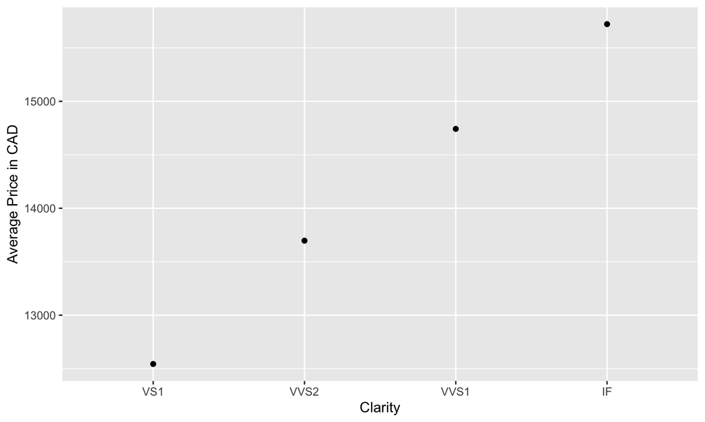

```r
ggplot(diamonds_final, aes(x = clarity, y = avgPrice)) +
  geom_point() +
  labs(x = "Clarity", y = "Average Price in CAD")
```

## Parting Comments

- `dplyr` is a necessity for data management, manipulaton, and cleaning.
- We learned some of the most popular *verbs* that `dplyr` has to offer.

## Parting Comments

- There are several functions that are in `dplyr` that haven’t been covered in this talk (see cheatsheet).
- `dtplyr`: `dplyr` for data tables (larger/high-dimensional/big data frames)
- `stringr`: Supplemental package that allows for string manipulation.
- `tidyr`: Converts data from wide to long format and vice versa.
- `tidyverse`: A suite of R packages developed to make data wrangling, manipulation, and visualization easier!

## Appendix:

## Subsetting a data frame in R

We can subset data frames using matrix notation.

- `A[i, j]`: The \(i^{th}\) row element and \(j^{th}\) column element of matrix `A`.
- `A[i, ]`: Extract the \(i^{th}\) row of matrix `A`.
- `A[, j]`: Extract the \(j^{th}\) column of matrix `A`.
- We can extract subsets of elements, rows, and columns based on their numerical position or satisfying certain conditions.

## Example 1:

```r
diamonds[, c("carat", "cut")]
```

```
## # A tibble: 53,940 x 2
##    carat cut
##    <dbl> <ord>
##  1 0.23  Ideal
##  2 0.21  Premium
##  3 0.23  Good
##  4 0.290 Premium
##  5 0.31  Good
##  6 0.24  Very Good
##  7 0.24  Very Good
##  8 0.26  Very Good
##  9 0.22  Fair
## 10 0.23  Very Good
## # … with 53,930 more rows
```

## Example 2:

```r
diamonds[1:3, ]
```

```
## # A tibble: 3 x 10
##   carat cut     color clarity depth table price     x     y     z
##   <dbl> <ord>   <ord> <ord>   <dbl> <dbl> <int> <dbl> <dbl> <dbl>
## 1  0.23 Ideal   E     SI2      61.5    55   326  3.95  3.98  2.43
## 2  0.21 Premium E     SI1      59.8    61   326  3.89  3.84  2.31
## 3  0.23 Good    E     VS1      56.9    65   327  4.05  4.07  2.31
```

## Example 3:

Alternatively, we can extract a coulumn of a data frame using the `$`.

```r
diamonds$price[1:10]
```

```
##  [1] 326 326 327 334 335 336 336 337 337 338
```

## Example 4:

```r
diamonds[diamonds$carat > 1, ]
```

```
## # A tibble: 17,502 x 10
##    carat cut       color clarity depth table price     x     y     z
##    <dbl> <ord>     <ord> <ord>   <dbl> <dbl> <int> <dbl> <dbl> <dbl>
##  1  1.17 Very Good J     I1       60.2    61  2774  6.83  6.9   4.13
##  2  1.01 Premium   F     I1       61.8    60  2781  6.39  6.36  3.94
##  3  1.01 Fair      E     I1       64.5    58  2788  6.29  6.21  4.03
##  4  1.01 Premium   H     SI2      62.7    59  2788  6.31  6.22  3.93
##  5  1.05 Very Good J     SI2      63.2    56  2789  6.49  6.45  4.09
##  6  1.05 Fair      J     SI2      65.8    59  2789  6.41  6.27  4.18
##  7  1.01 Fair      E     SI2      67.4    60  2797  6.19  6.05  4.13
##  8  1.04 Premium   G     I1       62.2    58  2801  6.46  6.41  4
##  9  1.2  Fair      F     I1       64.6    56  2809  6.73  6.66  4.33
## 10  1.02 Premium   G     I1       60.3    58  2815  6.55  6.5   3.94
## # … with 17,492 more rows
```

## Example 5:

We can also use the `$` to create a new column.

```r
diamonds$id <- 1:53940
diamonds[1:5, 5:11]
```

```
## # A tibble: 5 x 7
##   depth table price     x     y     z    id
##   <dbl> <dbl> <int> <dbl> <dbl> <dbl> <int>
## 1  61.5    55   326  3.95  3.98  2.43     1
## 2  59.8    61   326  3.89  3.84  2.31     2
## 3  56.9    65   327  4.05  4.07  2.31     3
## 4  62.4    58   334  4.2   4.23  2.63     4
## 5  63.3    58   335  4.34  4.35  2.75     5
```

## Aside: (Some) Logicals in R

| Operator | Description |
| --- | --- |
| `< (<=)` | less than (or equal to) |
| `> (>=)` | greater than (or equal to) |
| `== (!=)` | is equal (is not equal) |
| `!x` | not x |
| `x\|y` | x or y |
| `x&y` | x and y |

## Aside: Logicals in R

```r
x <- 2; y <- 4
x == 2 # Is x equal to 2?
```

```
## [1] TRUE
```

```r
x < 2 # Is x less than 2?
```

```
## [1] FALSE
```

```r
(x > 3) & (y < 10) # Is x greater than 3 AND y less than 10?
```

```
## [1] FALSE
```

```r
(x > 3) | (y < 10) # Is x greater than 3 OR y less than 10?
```

```
## [1] TRUE
```

## Aside: More (Logicals)

```r
x <- c(1, 2, 3, 4, NA, 5)
2 %in% x
```

```
## [1] TRUE
```

```r
anyNA(x)
```

```
## [1] TRUE
```

## arrange(): Sort the data set

- `arrange()` allows you to order rows by values of a column.
- `arrange(x, y)`: Arrange `x` by `y` (low to high).
- To arrange from highest to lowest replace `y` with `desc(y)`.

## arrange() in action

```r
arrange(diamonds, carat) # Carat size (smallest to largest)
```

```
## # A tibble: 53,940 x 11
##    carat cut       color clarity depth table price     x     y     z    id
##    <dbl> <ord>     <ord> <ord>   <dbl> <dbl> <int> <dbl> <dbl> <dbl> <int>
##  1   0.2 Premium   E     SI2      60.2    62   345  3.79  3.75  2.27    15
##  2   0.2 Premium   E     VS2      59.8    62   367  3.79  3.77  2.26 31592
##  3   0.2 Premium   E     VS2      59      60   367  3.81  3.78  2.24 31593
##  4   0.2 Premium   E     VS2      61.1    59   367  3.81  3.78  2.32 31594
##  5   0.2 Premium   E     VS2      59.7    62   367  3.84  3.8   2.28 31595
##  6   0.2 Ideal     E     VS2      59.7    55   367  3.86  3.84  2.3  31596
##  7   0.2 Premium   F     VS2      62.6    59   367  3.73  3.71  2.33 31597
##  8   0.2 Ideal     D     VS2      61.5    57   367  3.81  3.77  2.33 31598
##  9   0.2 Very Good E     VS2      63.4    59   367  3.74  3.71  2.36 31599
## 10   0.2 Ideal     E     VS2      62.2    57   367  3.76  3.73  2.33 31600
## # … with 53,930 more rows
```

## arrange() in action

```r
arrange(diamonds, desc(carat)) # Carat size (largest to smallest)
```

```
## # A tibble: 53,940 x 11
##    carat cut       color clarity depth table price     x     y     z    id
##    <dbl> <ord>     <ord> <ord>   <dbl> <dbl> <int> <dbl> <dbl> <dbl> <int>
##  1  5.01 Fair      J     I1       65.5    59 18018 10.7  10.5   6.98 27416
##  2  4.5  Fair      J     I1       65.8    58 18531 10.2  10.2   6.72 27631
##  3  4.13 Fair      H     I1       64.8    61 17329 10     9.85  6.43 27131
##  4  4.01 Premium   I     I1       61      61 15223 10.1  10.1   6.17 25999
##  5  4.01 Premium   J     I1       62.5    62 15223 10.0   9.94  6.24 26000
##  6  4    Very Good I     I1       63.3    58 15984 10.0   9.94  6.31 26445
##  7  3.67 Premium   I     I1       62.4    56 16193  9.86  9.81  6.13 26535
##  8  3.65 Fair      H     I1       67.1    53 11668  9.53  9.48  6.38 23645
##  9  3.51 Premium   J     VS2      62.5    59 18701  9.66  9.63  6.03 27680
## 10  3.5  Ideal     H     I1       62.8    57 12587  9.65  9.59  6.03 24329
## # … with 53,930 more rows
```

## arrange() in action

We can even arrange by multiple columns.

```r
arrange(diamonds, carat, color)
```

```
## # A tibble: 53,940 x 11
##    carat cut       color clarity depth table price     x     y     z    id
##    <dbl> <ord>     <ord> <ord>   <dbl> <dbl> <int> <dbl> <dbl> <dbl> <int>
##  1   0.2 Ideal     D     VS2      61.5    57   367  3.81  3.77  2.33 31598
##  2   0.2 Premium   D     VS2      62.3    60   367  3.73  3.68  2.31 31601
##  3   0.2 Premium   D     VS2      61.7    60   367  3.77  3.72  2.31 31602
##  4   0.2 Premium   E     SI2      60.2    62   345  3.79  3.75  2.27    15
##  5   0.2 Premium   E     VS2      59.8    62   367  3.79  3.77  2.26 31592
##  6   0.2 Premium   E     VS2      59      60   367  3.81  3.78  2.24 31593
##  7   0.2 Premium   E     VS2      61.1    59   367  3.81  3.78  2.32 31594
##  8   0.2 Premium   E     VS2      59.7    62   367  3.84  3.8   2.28 31595
##  9   0.2 Ideal     E     VS2      59.7    55   367  3.86  3.84  2.3  31596
## 10   0.2 Very Good E     VS2      63.4    59   367  3.74  3.71  2.36 31599
## # … with 53,930 more rows
```

## arrange() in action

We can even arrange by multiple columns.

```r
arrange(diamonds, color, carat)
```

```
## # A tibble: 53,940 x 11
##    carat cut       color clarity depth table price     x     y     z    id
##    <dbl> <ord>     <ord> <ord>   <dbl> <dbl> <int> <dbl> <dbl> <dbl> <int>
##  1  0.2  Ideal     D     VS2      61.5    57   367  3.81  3.77  2.33 31598
##  2  0.2  Premium   D     VS2      62.3    60   367  3.73  3.68  2.31 31601
##  3  0.2  Premium   D     VS2      61.7    60   367  3.77  3.72  2.31 31602
##  4  0.21 Premium   D     VS2      61.6    59   386  3.82  3.78  2.34 38277
##  5  0.21 Premium   D     VS2      60.6    60   386  3.85  3.81  2.32 38278
##  6  0.21 Premium   D     VS2      59.1    62   386  3.89  3.86  2.29 38279
##  7  0.21 Premium   D     VS2      58.3    59   386  3.96  3.93  2.3  38280
##  8  0.22 Premium   D     VS2      59.3    62   404  3.91  3.88  2.31    55
##  9  0.23 Very Good D     VS2      60.5    61   357  3.96  3.97  2.4     29
## 10  0.23 Very Good D     VS1      61.9    58   402  3.92  3.96  2.44    35
## # … with 53,930 more rows
```

## Exercise: The thrifty spender

**Exercise:** A customer comes looking to buy a diamond. However, they are on a tight budget and are only interested in big diamonds (regardless of other characteristics). Create a data frame `diamonds_thrifty` that arranges the data frame so that the customer can find the largest diamonds for the cheapest price.

## Exercise: The thrifty spender

```r
diamonds_thrifty <- arrange(diamonds, price, desc(carat))
diamonds_thrifty
```

```
## # A tibble: 53,940 x 11
##    carat cut       color clarity depth table price     x     y     z    id
##    <dbl> <ord>     <ord> <ord>   <dbl> <dbl> <int> <dbl> <dbl> <dbl> <int>
##  1 0.23  Ideal     E     SI2      61.5    55   326  3.95  3.98  2.43     1
##  2 0.21  Premium   E     SI1      59.8    61   326  3.89  3.84  2.31     2
##  3 0.23  Good      E     VS1      56.9    65   327  4.05  4.07  2.31     3
##  4 0.290 Premium   I     VS2      62.4    58   334  4.2   4.23  2.63     4
##  5 0.31  Good      J     SI2      63.3    58   335  4.34  4.35  2.75     5
##  6 0.24  Very Good J     VVS2     62.8    57   336  3.94  3.96  2.48     6
##  7 0.24  Very Good I     VVS1     62.3    57   336  3.95  3.98  2.47     7
##  8 0.26  Very Good H     SI1      61.9    55   337  4.07  4.11  2.53     8
##  9 0.22  Fair      E     VS2      65.1    61   337  3.87  3.78  2.49     9
## 10 0.23  Very Good H     VS1      59.4    61   338  4     4.05  2.39    10
## # … with 53,930 more rows
```

## Additional Exercise 1

The total depth percentage `depth` can be calculated as `2 * z / (x + y)`. Create a data frame that contains a column `depth2` that manually calculates depth. Then subset the data frame to only includes `price`, `depth` and `depth2`. Do you notice anything?

## Additional Exercise 1

```r
diamonds %>% mutate(depth2 = 2 * z / (x + y)) %>%
  select(price, depth, depth2)
```

```
## # A tibble: 53,940 x 3
##    price depth depth2
##    <int> <dbl>  <dbl>
##  1   326  61.5  0.613
##  2   326  59.8  0.598
##  3   327  56.9  0.569
##  4   334  62.4  0.624
##  5   335  63.3  0.633
##  6   336  62.8  0.628
##  7   336  62.3  0.623
##  8   337  61.9  0.619
##  9   337  65.1  0.651
## 10   338  59.4  0.594
## # … with 53,930 more rows
```

## Additional Exercise 2

Suppose we want to convert our prices (in USD) to three different currencies: British pound, Euro, and the Chinese Yuan. Create a data set that only contains the ID, carat, clarity, cut, and color of the diamond as well as the four has all four prices.

- How would you label the currencies so that you can easily tell them apart?
- You can rename a column name using the `dplyr` function `rename()`.
- `rename(x = y)`: Rename the column `y` to `x`.

## Additional Exercise 2

```r
diamonds %>% rename(USD = price) %>%
  mutate(EUR = 0.85 * USD,
         CYN = 6.95 * USD,
         GBP = 0.77 * USD) %>%
  select(carat, clarity, cut, color, USD, EUR, CYN, GBP)
```

```
## # A tibble: 53,940 x 8
##    carat clarity cut       color   USD   EUR   CYN   GBP
##    <dbl> <ord>   <ord>     <ord> <int> <dbl> <dbl> <dbl>
##  1 0.23  SI2     Ideal     E       326  277. 2266.  251.
##  2 0.21  SI1     Premium   E       326  277. 2266.  251.
##  3 0.23  VS1     Good      E       327  278. 2273.  252.
##  4 0.290 VS2     Premium   I       334  284. 2321.  257.
##  5 0.31  SI2     Good      J       335  285. 2328.  258.
##  6 0.24  VVS2    Very Good J       336  286. 2335.  259.
##  7 0.24  VVS1    Very Good I       336  286. 2335.  259.
##  8 0.26  SI1     Very Good H       337  286. 2342.  259.
##  9 0.22  VS2     Fair      E       337  286. 2342.  259.
## 10 0.23  VS1     Very Good H       338  287. 2349.  260.
## # … with 53,930 more rows
```